# Lecture 3 Exercises

Jannik

11/20/2020

# Setup

This is a setup chunk I use quite a lot, because the people receiving the report usually don’t care about the warnings and messages, they are meant for us when exploring the data, not the final report:

```r
knitr::opts_chunk$set(echo = TRUE, message = FALSE, warning = FALSE)
```

Load your libraries (and data) near the top so that any dependencies are clear early on:

```r
library(tidyverse)

theme_set(theme_linedraw())
```

# One Set of Solutions

## Tidy Data

1. Imagine for a second this whole pandemic thing is not going on and we are planning a vacation. Of course, we want to choose the safest airline possible, so we download data about incident reports. You can find it in the *data* folder[^1].
2. Instead of the `type_of_event` and `n_events` columns we would like to have one column per type of event, where the values are the count for this event.
3. Which airlines had the least fatal accidents, standardized to the distance theses airlines covered, in the two time ranges?
4. Even if something where to go wrong, which airlines have the best record when it comes to fatalities per fatal accident?
5. Create an informative plot to highlight your discoveries. It might be beneficial to only plot e.g. the highest or lowest scoring Airlines. One of the `slice_` functions will help you there. And to make your plot prettier, you will have to look into `fct_reorder` again.

First, we read in the data.

```r
airlines <- read_csv("data/airlines.csv")
```

… and tidy it.

```r
tidy_airlines <- airlines %>%
  pivot_wider(names_from = type_of_event,
              values_from = n_events)
```

Next, we find the top and bottom spots and stack the two resulting tables on top of each other with `bind_rows`:

```r
accidents_per_km <- tidy_airlines %>%
  group_by(airline) %>%
  summarise(
    avail_seat_km_per_week = mean(avail_seat_km_per_week),
    fatal_accidents = mean(fatal_accidents)
  ) %>%
  mutate(accidents_per_km = fatal_accidents / avail_seat_km_per_week) %>%
  arrange(accidents_per_km, desc(avail_seat_km_per_week))

top_airlines <- accidents_per_km %>%
  slice_head(n = 5)

worst_airlines <- accidents_per_km %>%
  slice_tail(n = 5)

top_and_worst <- bind_rows(top_airlines, worst_airlines)
```

This is what our table looks like now (printing it pretty):

```r
top_and_worst %>%
  knitr::kable()
```

| airline | avail_seat_km_per_week | fatal_accidents | accidents_per_km |
| --- | --- | --- | --- |
| Southwest Airlines | 3276525770 | 0.0 | 0 |
| British Airways* | 3179760952 | 0.0 | 0 |
| Cathay Pacific* | 2582459303 | 0.0 | 0 |
| Qantas* | 1917428984 | 0.0 | 0 |
| Air Canada | 1865253802 | 0.0 | 0 |
| Royal Air Maroc | 295705339 | 1.5 | 0 |
| Philippine Airlines | 413007158 | 2.5 | 0 |
| Aeroflot* | 1197672318 | 7.5 | 0 |
| Ethiopian Airlines | 488560643 | 3.5 | 0 |
| Pakistan International | 348563137 | 2.5 | 0 |

There where questions about handling `NA` and `NAN`s, so we create some artificially and showcase another way of displaying a pretty table:

```r
with_nas <- top_and_worst %>%
  mutate(fatal_accidents = fatal_accidents / fatal_accidents)

head(with_nas) %>%
  rmarkdown::paged_table()
```

| airline | avail_seat_km_per_week | fatal_accidents | accidents_per_km |
| --- | --- | --- | --- |
| Southwest Airlines | 3276525770 | NaN | 0.000000e+00 |
| British Airways* | 3179760952 | NaN | 0.000000e+00 |
| Cathay Pacific* | 2582459303 | NaN | 0.000000e+00 |
| Qantas* | 1917428984 | NaN | 0.000000e+00 |
| Air Canada | 1865253802 | NaN | 0.000000e+00 |
| Royal Air Maroc | 295705339 | 1 | 5.072617e-09 |

Then we deal with them, either using the generic function `ifelse` or the more specialized function `replace_na`.

```r
with_nas %>%
  mutate(fatal_accidents = ifelse(is.na(fatal_accidents), 0, fatal_accidents)) %>%
  head(3)
```

```
## # A tibble: 3 x 4
##   airline            avail_seat_km_per_week fatal_accidents accidents_per_km
##   <chr>                               <dbl>           <dbl>            <dbl>
## 1 Southwest Airlines             3276525770               0                0
## 2 British Airways*               3179760952               0                0
## 3 Cathay Pacific*                2582459303               0                0
```

```r
with_nas %>%
  replace_na(list(fatal_accidents = 0)) %>%
  head(3)
```

```
## # A tibble: 3 x 4
##   airline            avail_seat_km_per_week fatal_accidents accidents_per_km
##   <chr>                               <dbl>           <dbl>            <dbl>
## 1 Southwest Airlines             3276525770               0                0
## 2 British Airways*               3179760952               0                0
## 3 Cathay Pacific*                2582459303               0                0
```

Time for a plot:

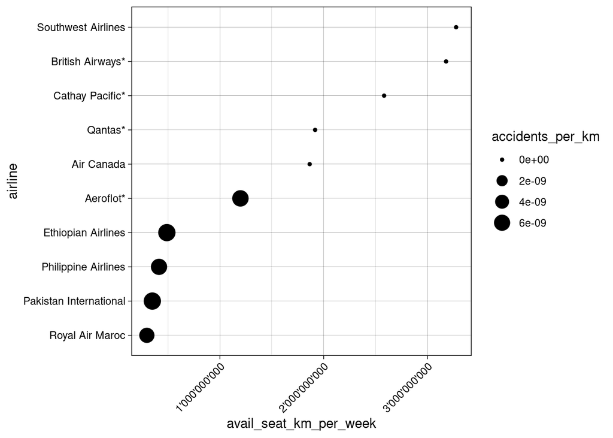

```r
top_and_worst %>%
  mutate(airline = fct_reorder(airline, avail_seat_km_per_week)) %>%
  ggplot(aes(avail_seat_km_per_week, airline, size = accidents_per_km)) +
  geom_point() +
  scale_x_continuous(labels = scales::number_format(big.mark = "'")) +
  theme(
    axis.text.x = element_text(angle = 45, hjust = 1)
  )
```

I also saw another version in the solutions that kept the two time spans separated to show a development. Let me recreate a version of it here. I am also using the opportunity to play around with the `ggthemes` package and have some fun.

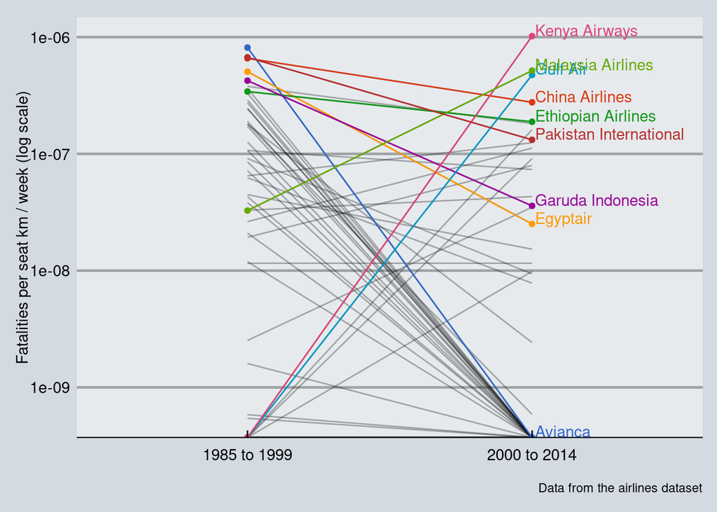

```r
airlines_fatalities <- tidy_airlines %>%
  mutate(
    year_range = case_when(
      year_range == "00_14" ~ "2000 to 2014",
      year_range == "85_99" ~ "1985 to 1999"
    ),
    fat_per_km = fatalities / avail_seat_km_per_week
  )

top_contestants <- airlines_fatalities %>%
  group_by(year_range) %>%
  slice_max(fat_per_km, n = 5) %>%
  distinct(airline)

label_these <- airlines_fatalities %>%
  filter(airline %in% top_contestants$airline)

airlines_fatalities %>%
  ggplot(aes(year_range, fat_per_km, group = airline)) +
  geom_line(alpha = 0.3) +
  geom_line(data = label_these, aes(color = airline)) +
  geom_point(data = label_these, aes(color = airline)) +
  geom_text(data = filter(label_these, year_range == "2000 to 2014"),
            aes(label = airline,
                color = airline), hjust = 0, vjust = 0,
            nudge_x = 0.01) +
  scale_y_log10() +
  labs(x = "",
       y = "Fatalities per seat km / week (log scale)",
       titel = "Changes across the two time ranges",
       caption = "Data from the airlines dataset") +
  ggthemes::scale_color_gdocs() +
  ggthemes::theme_economist() +
  guides(color = "none") +
  theme(panel.grid.major.y = element_line(color = alpha("black", 0.3)),
        panel.background = element_rect(fill = "#E6EAED"),
        plot.background = element_rect(fill = "#D4DAE2"))
```

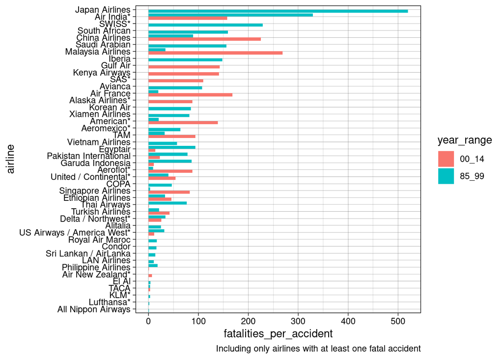

```r
tidy_airlines %>%
  filter(fatal_accidents > 0) %>%
  mutate(fatalities_per_accident = fatalities / fatal_accidents) %>%
  mutate(airline = fct_reorder(airline, fatalities_per_accident)) %>%
  ggplot(aes(fatalities_per_accident, airline, fill = year_range)) +
  geom_col(position = position_dodge(preserve = "single")) +
  labs(caption = "Including only airlines with at least one fatal accident")
```

A question about removing NAs.

```r
x <- c(1, 2, NA)
min(x, na.rm = TRUE)
```

```
## [1] 1
```

## Functions and Iteration

1. You are going strong so far! Programming can sometimes be frustrating, so I think what we need is someone to motivate us. R is up to the task. Write a function that takes a name, like “Jannik” or your name, and spits out a motivational message that includes the name. Make sure to also test it and show that it works.
2. Now that you have a motivational machine, you need to make sure to motivate the greatest amount of people. Use the `map` function to apply your function to a whole vector of names.

I also gave a brief overview of what makes a safe function. If involves the concept of pure functions vs. side effects.

```r
some_global_variable <- "I am a global variable"

shout <- function(name, times) {
  # body
  big_name <- toupper(name)
  text <- rep(big_name, times = times)
  text <- paste(some_global_variable, text)
  return(text)
}

our_result <- shout("I love R", times = 1)

some_global_variable <- "I am a different thing now"

our_result2 <- shout("I love R", times = 1)

our_result
```

```
## [1] "I am a global variable I LOVE R"
```

```r
our_result2
```

```
## [1] "I am a different thing now I LOVE R"
```

```r
motivation <- function(name) {
  message("Currently processing:", name)
  paste("you are doing great", name)
}

motivation("Jannik")
```

```
## [1] "you are doing great Jannik"
```

```r
names <- c("Jannik", "Franzi", "Julia")
map(names, motivation)
```

```
## [[1]]
## [1] "you are doing great Jannik"
##
## [[2]]
## [1] "you are doing great Franzi"
##
## [[3]]
## [1] "you are doing great Julia"
```

In this example, the map function would not even have been necessary, because `paste` is already vectorized:

```r
motivation(name = names)
```

```
## [1] "you are doing great Jannik" "you are doing great Franzi"
## [3] "you are doing great Julia"
```

# Q and A Section

```r
result <- paste("text", "more text")
```

```r
result <- print("hello!")
```

```
## [1] "hello!"
```

```r
result
```

```
## [1] "hello!"
```

```r
message("this is a message")
warning("oh no, a warning")
```

[^1]: source: [tidytuesday](https://github.com/rfordatascience/tidytuesday/tree/master/data/2018/2018-08-07)